# DV 4

Author

Matthew O’Stricker

# Chapter 4 - Data Visualization

Here, we are going to practice and reinforce some of the key ideas from chapter 4.

## Question 1

We are going to work with a dataset of TV Ratings taken from IMDB. Let’s read it in and see what we have.

```r
library(tidyverse)

# Read in the data
tv_ratings <- read_csv("https://raw.githubusercontent.com/vaiseys/dav-course/main/Data/tv_ratings.csv")

# Glimpse the data
glimpse(tv_ratings)
```

```
Rows: 2,266
Columns: 7
$ titleId      <chr> "tt2879552", "tt3148266", "tt3148266", "tt3148266", "tt31…
$ seasonNumber <dbl> 1, 1, 2, 3, 4, 1, 2, 1, 2, 3, 4, 5, 6, 7, 8, 1, 1, 1, 1, …
$ title        <chr> "11.22.63", "12 Monkeys", "12 Monkeys", "12 Monkeys", "12…
$ date         <date> 2016-03-10, 2015-02-27, 2016-05-30, 2017-05-19, 2018-06-…
$ av_rating    <dbl> 8.4890, 8.3407, 8.8196, 9.0369, 9.1363, 8.4370, 7.5089, 8…
$ share        <dbl> 0.51, 0.46, 0.25, 0.19, 0.38, 2.38, 2.19, 6.67, 7.13, 5.8…
$ genres       <chr> "Drama,Mystery,Sci-Fi", "Adventure,Drama,Mystery", "Adven…
```

```
## Rows: 2,266
## Columns: 7
## $ titleId      <chr> "tt2879552", "tt3148266", "tt3148266", "tt3148266", "tt31…
## $ seasonNumber <dbl> 1, 1, 2, 3, 4, 1, 2, 1, 2, 3, 4, 5, 6, 7, 8, 1, 1, 1, 1, …
## $ title        <chr> "11.22.63", "12 Monkeys", "12 Monkeys", "12 Monkeys", "12…
## $ date         <date> 2016-03-10, 2015-02-27, 2016-05-30, 2017-05-19, 2018-06-…
## $ av_rating    <dbl> 8.4890, 8.3407, 8.8196, 9.0369, 9.1363, 8.4370, 7.5089, 8…
## $ share        <dbl> 0.51, 0.46, 0.25, 0.19, 0.38, 2.38, 2.19, 6.67, 7.13, 5.8…
## $ genres       <chr> "Drama,Mystery,Sci-Fi", "Adventure,Drama,Mystery", "Adven…
```

We notice that each row is a season-title pair. Then we get the average rating for that season of that show, and the corresponding genre.

The first thing that we are going to look at is how rating develops across seasons, for different genres. To do this, we need shows that have lasted a while. The following bit of code counts how many seasons each show has and then keeps those shows that have had 5 seasons or more.

```r
tv_long <- tv_ratings %>%
  group_by(title) %>%
  summarise(num_seasons = n()) %>%
  ungroup() %>%
  left_join(tv_ratings, by = "title")

tv_long <- tv_long %>%
  filter(num_seasons >= 5)
```

Use `tv_long` to make a line plot to trace how average ratings evolve across seasons. Remember to use the group aesthetic so that each line represents one show.

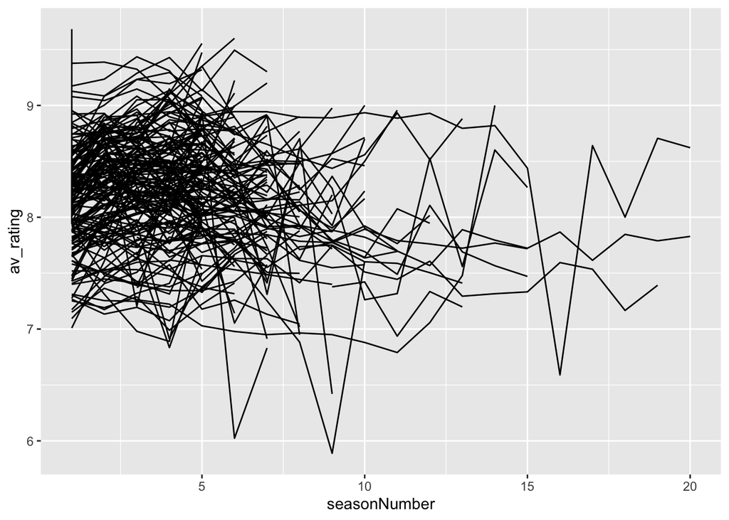

```r
ggplot(tv_long, aes(x = seasonNumber, y = av_rating, group = title)) +
  geom_line()
```

It should look fairly messy. Can you draw any conclusions from it?

**Answer:** I cannot draw any conclusions from the line plot as it is too messy to provide any informational takeaways.

## Question 2

Facet the plot above by `genres` so that we can see patterns more clearly.

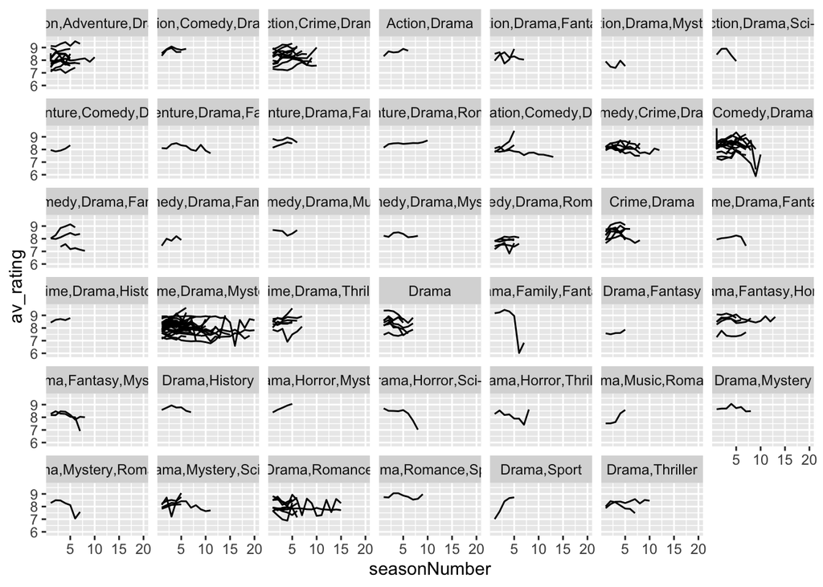

```r
ggplot(tv_long, aes(x = seasonNumber, y = av_rating, group = title)) +
  geom_line() +
  facet_wrap(~genres)
```

What shows tend to last longer? Do ratings change much across seasons? Can you identify that show on `Drama, Family, Fantasy` whose ratings just plummeted?

**Answer:** Shows in the `Crime, Drama, and Mystery` genre tend to last longer compared to the other shows listed. The way in which ratings change across seasons depends on the genre. For some like `Crime, Drama, Mystery`, the ratings do not change much across seasons. However, there are genres like `Drama, Family, Fantasy` see drastic changes of ratings across seasons. The show on `Drama, Family, Fantasy` was `Are You Afraid of the Dark?`

## Question 3

Let’s look at the `genres` that show up in the best rated shows.

First, filter the original data set - `tv_ratings` - so that it only includes rows where the average rating is higher or equal than 9.

```r
tv_ratings_nine <- tv_ratings |>
  filter(av_rating >= 9)
```

Make a barplot where the x-axis is `genre`.

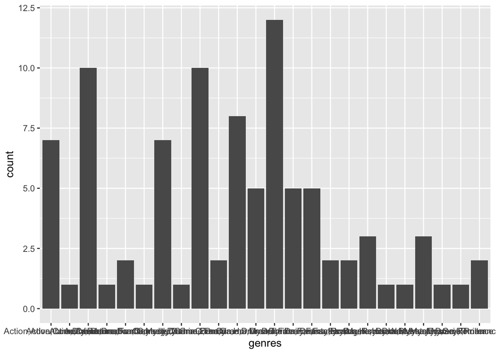

```r
ggplot(tv_ratings_nine, aes(x = genres)) +
  geom_bar()
```

The result should be hard to read - the names of the genres are quite long. Add `coord_flip()` to the end of your ggplot call and watch the results get clearer. Tell me what `coord_flip()` does.

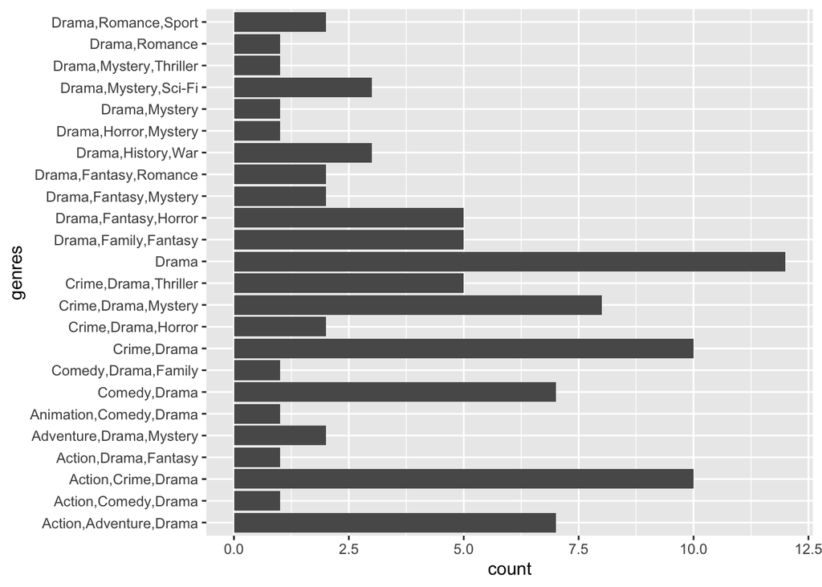

```r
ggplot(tv_ratings_nine, aes(x = genres)) +
  geom_bar() +
  coord_flip()
```

**Answe**r**:** `coord_flip` flips the coordinates from the x axis to the y axis, which is helpful in this case to allow for us to read the names of the genres better.

What is the genre with the most top-rated shows?

**Answer:** The `genre` with the most top-rated shows is `Drama`.

## Question 4

As a comedy fan, I am quite distraught by the results. I want to compare the range of average ratings that comedies and dramas get. Surely there are many bad comedies but the best comedies should rival the best dramas. Right?

For this, we need to do a bit of wrangling that I am going to walk you through.

First, because the `genres` names are so convoluted, I am going to classify everything that includes the word “Comedy” as a comedy.

```r
comedies_dramas <- tv_ratings %>%
  mutate(is_comedy = if_else(str_detect(genres, "Comedy"),
                             1,
                             0)) %>% # If it contains the word comedy then 1, else 0
  filter(is_comedy == 1 | genres == "Drama") %>% # Keep comedies and dramas
  mutate(genres = if_else(genres == "Drama", # Make it so that we only have those two genres
                          "Drama",
                          "Comedy"))

glimpse(comedies_dramas)
```

```
Rows: 684
Columns: 8
$ titleId      <chr> "tt0312081", "tt0312081", "tt0312081", "tt1225901", "tt12…
$ seasonNumber <dbl> 1, 2, 3, 1, 2, 3, 4, 5, 1, 2, 1, 25, 1, 1, 2, 3, 4, 5, 1,…
$ title        <chr> "8 Simple Rules", "8 Simple Rules", "8 Simple Rules", "90…
$ date         <date> 2002-09-17, 2003-11-04, 2004-11-12, 2009-01-03, 2009-11-…
$ av_rating    <dbl> 7.5000, 8.6000, 8.4043, 7.1735, 7.4686, 7.6858, 6.8344, 7…
$ share        <dbl> 0.03, 0.10, 0.06, 0.40, 0.14, 0.10, 0.04, 0.01, 0.48, 0.4…
$ genres       <chr> "Comedy", "Comedy", "Comedy", "Comedy", "Comedy", "Comedy…
$ is_comedy    <dbl> 1, 1, 1, 1, 1, 1, 1, 1, 1, 1, 0, 1, 1, 1, 1, 1, 1, 1, 1, …
```

```
## Rows: 684
## Columns: 8
## $ titleId      <chr> "tt0312081", "tt0312081", "tt0312081", "tt1225901", "tt12…
## $ seasonNumber <dbl> 1, 2, 3, 1, 2, 3, 4, 5, 1, 2, 1, 25, 1, 1, 2, 3, 4, 5, 1,…
## $ title        <chr> "8 Simple Rules", "8 Simple Rules", "8 Simple Rules", "90…
## $ date         <date> 2002-09-17, 2003-11-04, 2004-11-12, 2009-01-03, 2009-11-…
## $ av_rating    <dbl> 7.5000, 8.6000, 8.4043, 7.1735, 7.4686, 7.6858, 6.8344, 7…
## $ share        <dbl> 0.03, 0.10, 0.06, 0.40, 0.14, 0.10, 0.04, 0.01, 0.48, 0.4…
## $ genres       <chr> "Comedy", "Comedy", "Comedy", "Comedy", "Comedy", "Comedy…
## $ is_comedy    <dbl> 1, 1, 1, 1, 1, 1, 1, 1, 1, 1, 0, 1, 1, 1, 1, 1, 1, 1, 1, …
```

Now, you should have a dataset with shows that are categorized as either drama or comedies.

Plot a density plot that shows the distribution of average ratings for both comedies and dramas.

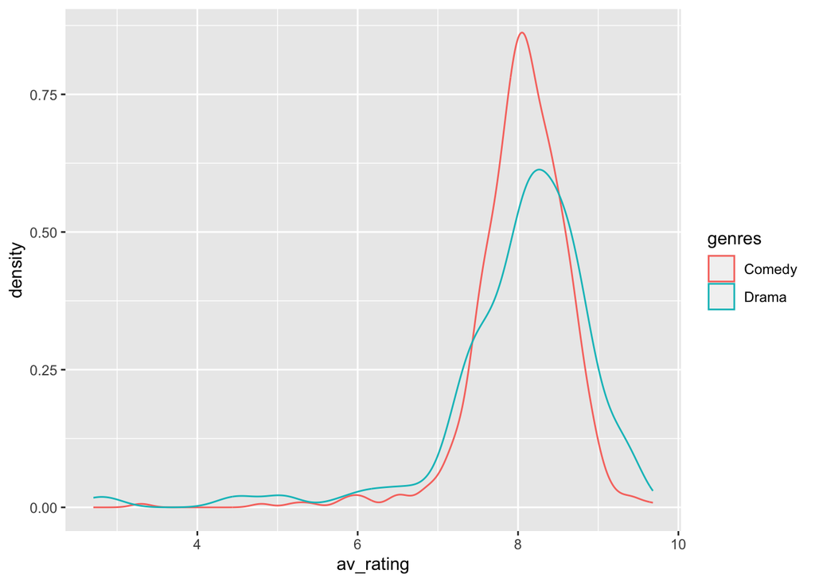

```r
ggplot(comedies_dramas, aes(x = av_rating,
                            group = genres,
                            color = genres)) +
  geom_density()
```

How does my prediction above hold? Are dramas rated higher?

**Answer:** The `Drama` genre does have a higher amount of shows that have a higher rating than `Comedy`; however, it does a slightly higher amount of shows that have low ratings compared to the `Comedy` genre.

## Question 5

Let’s experiment with different ways of visualizing this. First, do the same plot using histograms.

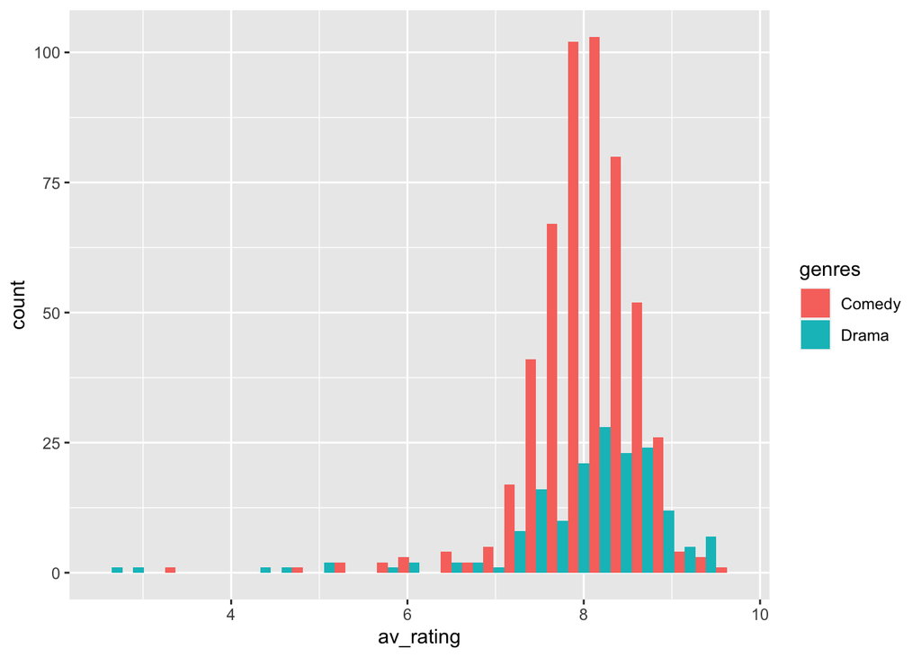

```r
ggplot(comedies_dramas, aes(x = av_rating,
                            group = genres,
                            fill = genres)) +
  geom_histogram(position = "dodge")
```

What additional information does this give you?

**Answer:** It lets me know that there is a larger number of shows in the `Comedy` genre that were accounted for in comparison to the `Drama` genre. This could have played a role in the density plot’s appearance.

> Hint: look at the size of the bars. I probably categorized way too many shows as “comedies”. I had to stack the deck.

Now, use `geom_freqpoly()`. What do you notice? Of the three plots, which one do you think it’s more informative?

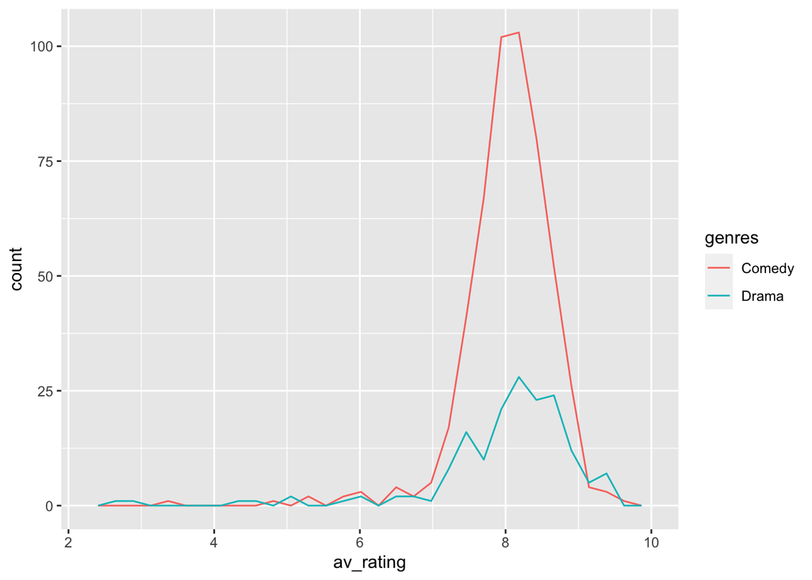

```r
ggplot(comedies_dramas, aes(x = av_rating,
                            group = genres,
                            color = genres)) +
  geom_freqpoly()
```

**Answer:** I think the freqpoly plot was the most informative plot because it is easy to understand and depicts the drastic difference in the number of `Comedy` shows that were recorded in comparison to the `Drama` shows as well as their `av_rating`.

## Question 6

Let’s now explore whether the actual quality of the show corresponded to how many people were paying attention. The column `share` indicates the share of viewership that that show and season acquired. We are going to examine the relationship between average rating and share of viewership.

Take our `comedies_dramas` dataset and make a plot where average rating is on the x-axis and share on the y-axis. Use `geom_bin_2d()` to make the plot.

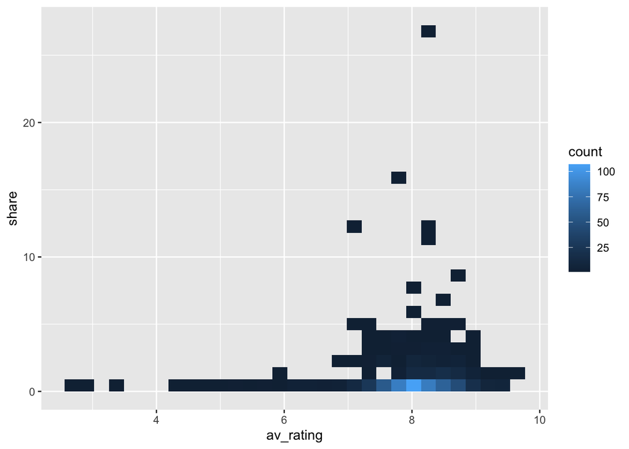

```r
ggplot(comedies_dramas, aes(x = av_rating, y = share)) +
  geom_bin_2d()
```

What do you see? What additional information does this give you in comparison to a scatter plot?

I notice that the majority of the shows did not get a `share` that was above 10, which does not seem too high to me. Further, there was a high concentration of shows with an `av_rating` of 8 that have `share`s that were at or near 0. In comparison to a scatter plot, this plot tells you the density of certain points on the plot that would appear overlapped on a scatter plot. By having the density meter, it makes the data easier to read and better distinguish certain points on the plot.

Now add `genres` to the fill aesthetic. What patterns do you see? Can you identify that big outlier that apparently captured the nation?

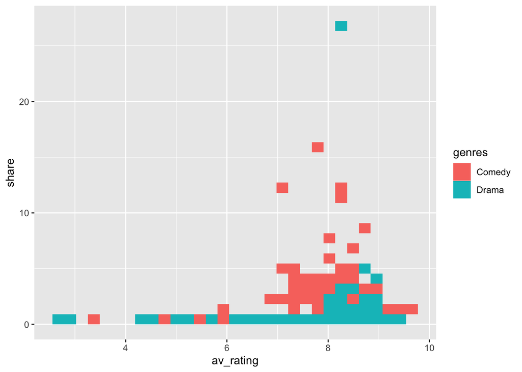

```r
ggplot(comedies_dramas, aes(x = av_rating, y = share, fill = genres)) +
  geom_bin_2d()
```

**Answer:** The patterns I notice is that the `Drama` genres typically dominated the lower `share` numbers in comparison to the `Comedy` shows with the exception of the outlier shown above. The outlier that captured the nation was a `Drama` show called Dekalog.